# Student Funding and Graduation Outcomes

Scott Burghart

2024-01-11

# 1 Introduction

This report analyses the effect that the amount of TA funding has on the degree outcomes and the time to degree for graduate students in the College of Natural Sciences at UT Austin for cohorts 2012-2017. The below analyses involve only students who entered a graduate program seeking a PhD. Data come from the Graduate School Information System (GSIS). The Neuroscience program is not included because their data are not available for download via GSIS.

# 2 Total Support

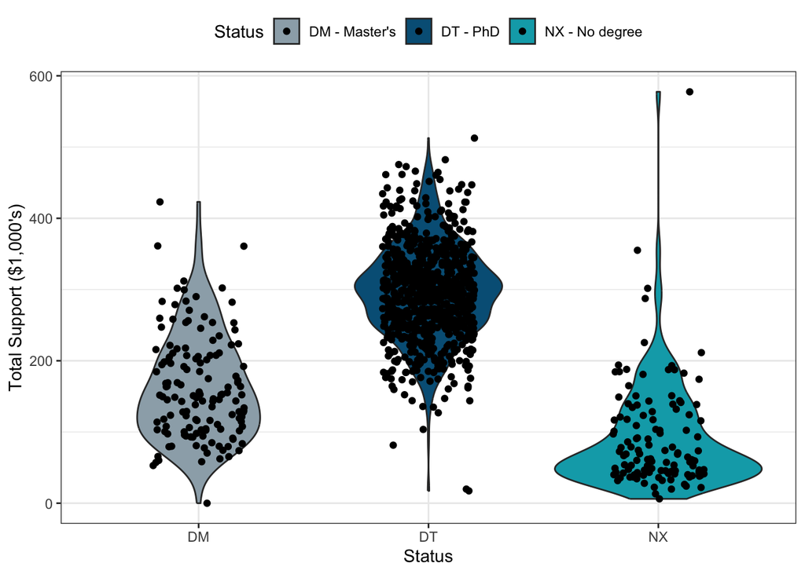

Figure 2.1: The relationship between the total amount of support received by students and their degree outcomes

Unsurprisingly, significantly more money is ultimately spent on students who finish their degrees. For students who left with a PhD, an average of $296,297 was invested, compared to $162,574 for students departing with a master’s and $92,435 for students leaving with no degree. As an aside, though not included in the figure, due to increasing costs of student support, it was calculated taht students currently enrolled in PhD programs have already received an average of $322,937.

# 3 Form of Support

Of more interest for this report is the form student support takes and its effects on degree outcomes and time to degree (TTD). Specifically, do students who receive more support in the form of AI or TA (AITA) assignments take longer to finish or are they at a greater risk of departing the program without completing their PhD? This is commplicated by the fact that the number of semesters a student spends as an AITA is not readily available. The dollar amount of support as an AITA can be used as a proxy for the number of semesters the student was employed in an instructional role but this is a less than optimal measure of AITA semesters since the cohorts examined span a time of aggressive stipend increases within the college. As such, AITA semesters towards the end of the period examined will be weighted more heavily. Additionally, AI assignments pay 6% more than TA assignments and the source data makes no distinction between the two. To partially control for these issues, the percentage of total support as an AITA was used.

## 3.1 Degree Outcomes

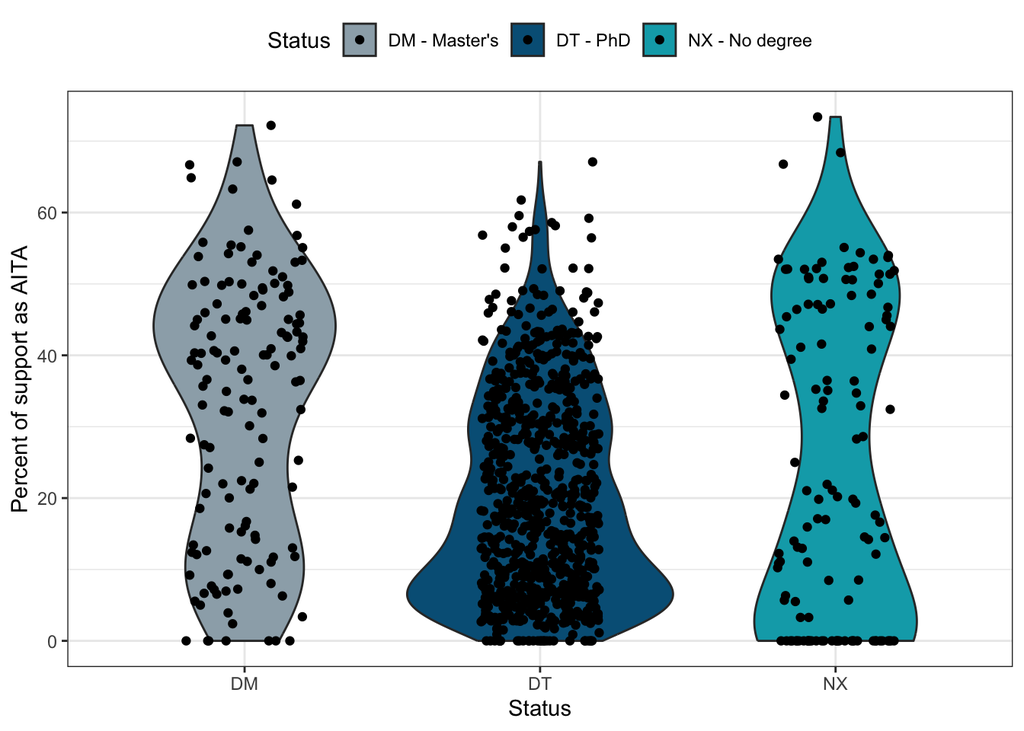

Figure 3.1: The relationship between percent of support as an AITA and degree outcomes

The percentage of total support attributed to AITA work assignments was different between the degree outcome groups (Kruskal-Wallis p < 0.05). On average students who finished with a PhD received 19.9% of their support as an AITA while those who left without a degree averaged 24.5% and those who finished with a master’s received 32.6%.

It is important to note that students entering two of the largest programs (Chemistry and Physics), almost invariably TA their first year. This will increase the average annual amount of AITA support for students who stay less than five years and thus will, thus, usually appear in the DM or NX category. To examine if these two programs had an undue effect, they were removed and the analysis was repeated.

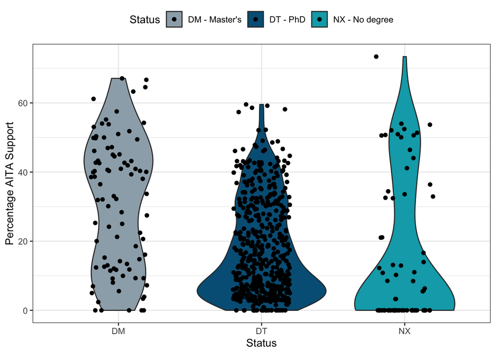

Figure 3.2: The relationship between percentage support as an AITA and degree outcomes with Physics and Chemistry removed

With Chemistry and Physics students removed from the analysis, the percentage of funding from being an AITA was virtually identical between students who finished with a PhD and those who left with no degree at 17.7% and 16.0%, respectively. The average percentage of AITA support for students that left with a master’s, however, was almost twice as much at 31.1%

## 3.2 Time to Degree

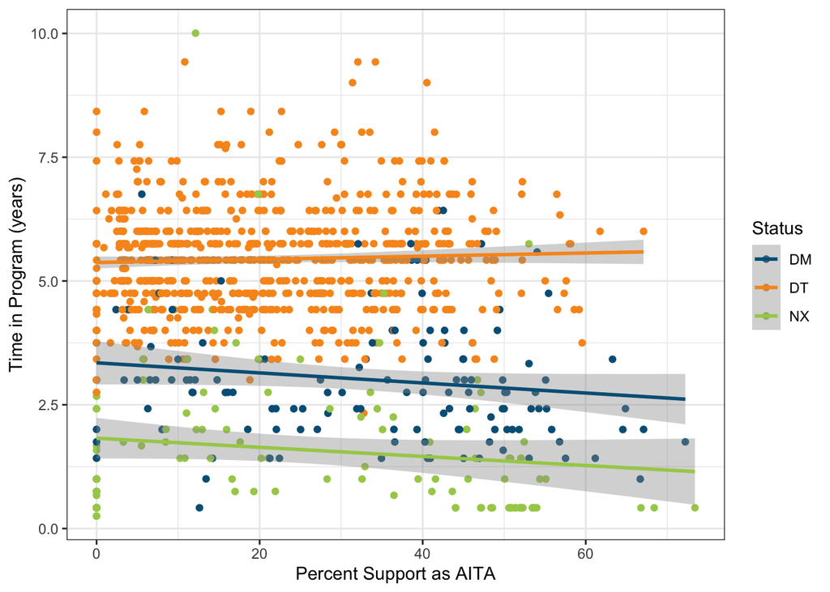

Figure 3.3: Relationship between the percentage of AITA support and TTD

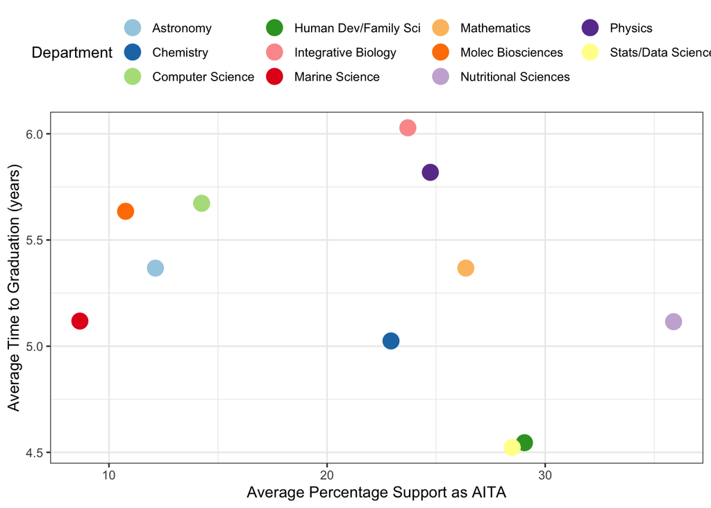

Figure 3.4: Relationship between percentage of AITA funding and TTD between different programs

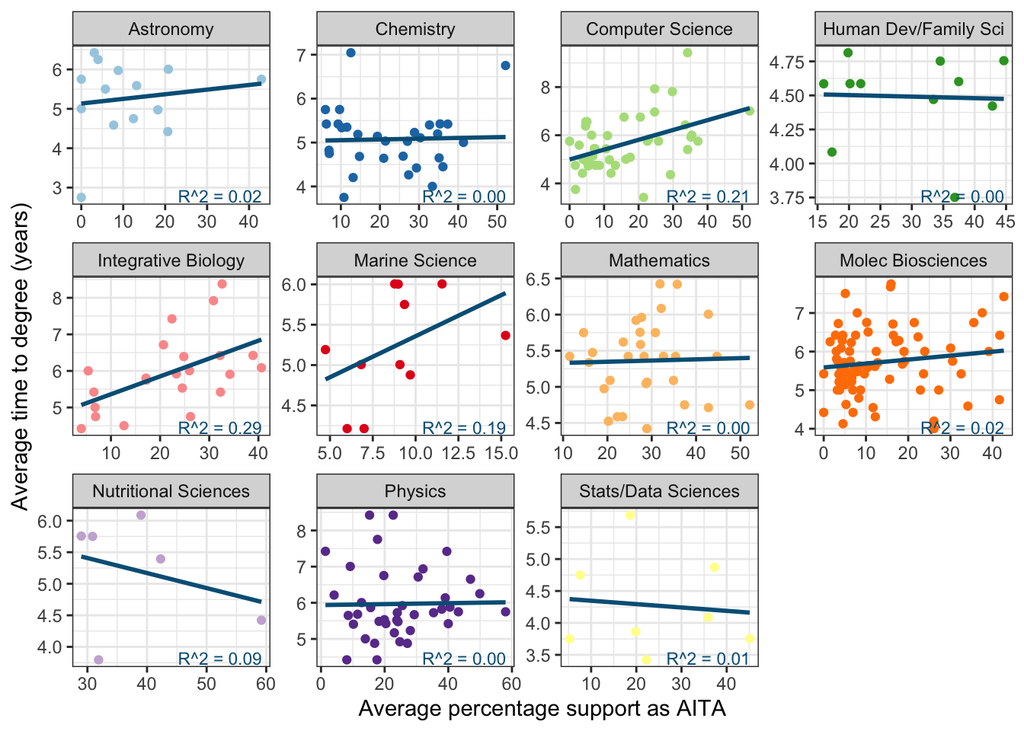

Figure 3.5: Relationship between average annual AITA funding and TTD of PhD students in different programs

Across the college, time to degree (TTD) did not show a positive relationship to the percentage of support as an AITA.

In Figure 3.5, each point represents an individual PI within each program. Within each department, the average TTD versus percentage support as an AITA did have some positive slopes, but R-squared values were very low. The highest values occurred in Integrative Biology and Computer Science.